# Homework 8

*Question 7* Do the same as you did for 6, except plot voter turnout on the y-axis instead. To do this, use (mccain + obama)/VAP as a measure for turnout. (Note: There are some units where the presidential vote-share is greater than the voting-age population. This is due to estimation errors in the data. Ignore these cases by constraining the y-axis to only contain values between 0 and 1.) What do you make of the relationship?

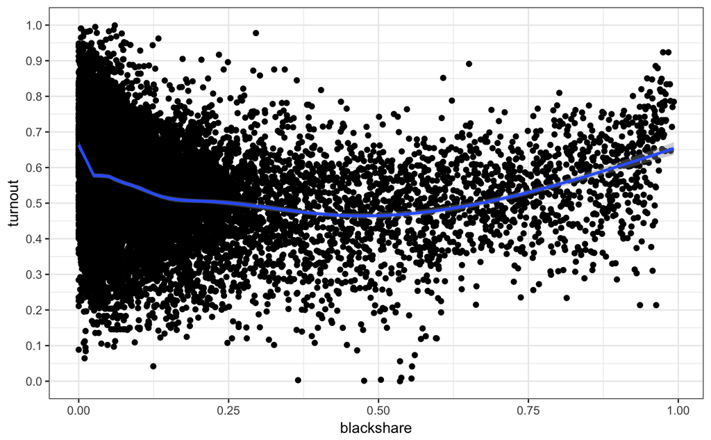

```r
q7 <- fl %>%
  filter(VAP > 200) %>%
  mutate(blackshare = BlackVAP/(VAP),
         turnout = (mccain + obama)/VAP)
ggplot(data = q7, aes(x=blackshare,y=turnout)) + geom_point() + geom_smooth() + scale_y_continuous(breaks= seq(0,1,.1), limits = c(0,1) ) +theme_bw()
```

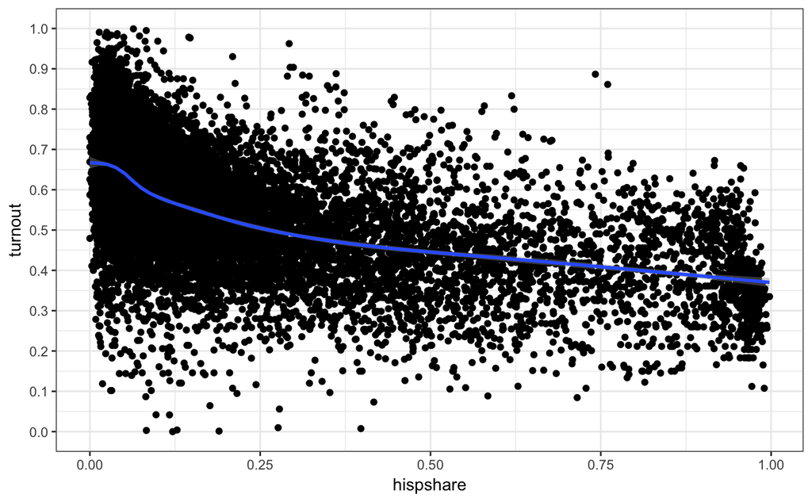

```r
q7 <- fl %>%
  filter(VAP > 200) %>%
  mutate(hispshare = HispVAP/(VAP),
          turnout = (mccain + obama)/VAP)
ggplot(data = q7, aes(x=hispshare,y=turnout)) + geom_point() + geom_smooth() +theme_bw() + scale_y_continuous(breaks= seq(0,1,.1), limits = c(0,1) )
```

*Question 8*

Calculate McCain’s share of the two-party vote for each of Florida’s 27 Congressional District and plot the results. Arrange the Districts along the x-axis by their degree of support for McCain (from least to most). Then plot McCain’s vote share along the y-axis. Your plot should look like the one below. What do you notice about the distribution of the partisan vote?

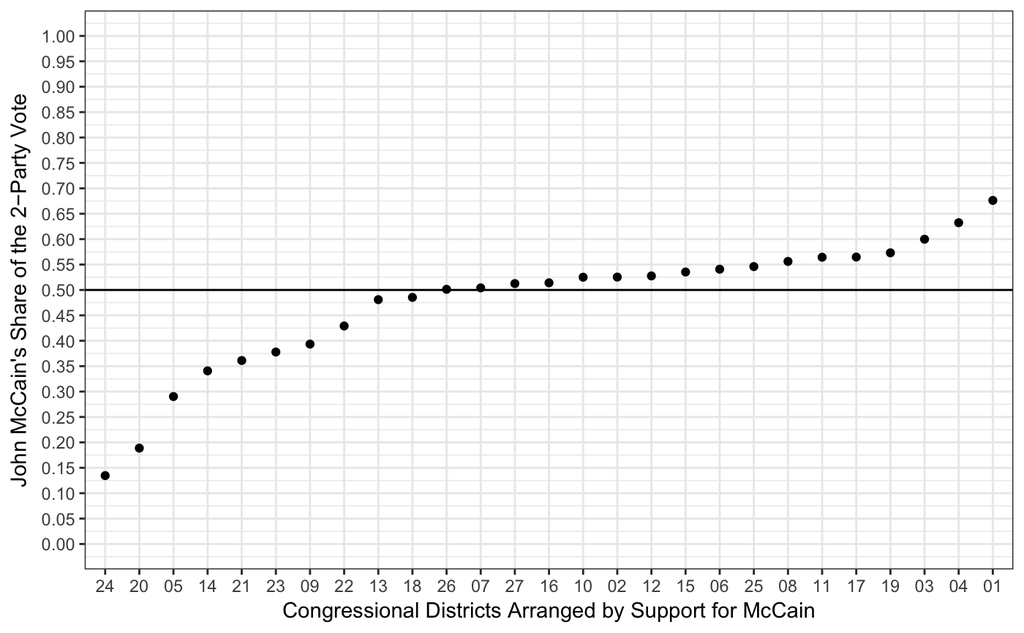

There are more districts that swing republican despite the fact that overall in the state, there are more democrats (looks like packing!).

*Question 9* Take a look at the dataframe sims. Each column in the dataframe is the result of a computer simulated redistricting procedure that assigns each observation in the fl dataset to one of the 27 Congressional Districts. Like Florida’s actual Congressional Districts, these districts are drawn to be equally apportioned, compact, and contiguous. However, unlike Florida’s Congressional Districts, these Districts are NOT drawn by politicians who have the incentive to gerrymander. Instead, they are drawn by a computer, without partisan intent.

Your task is to calculate the McCain vote-share for every district in each of the 100 simulations. Then, for each simulation, count the number of districts where McCain has a majority of the two-party vote. Report the mean and standard deviation. Does the actual number of McCain-Majority districts fall within 2 standard deviations of the simulated mean?

(NOTE: sims has 100 columns corresponding to the results of 100 simulations. In each column there is a set of district numbers that are assigned to the 15,640 units in the dataframe fl. The rows of sims directly map to the rows of fl such that the first row of sims corresponds to the first row of fl, the second row of sims corresponds to the second row of fl, and so on.)

```r
test <- cbind(last, sims)
test <- test %>%
  gather("simulation","district",3:102)%>%
  group_by(simulation, district) %>%
  summarize(mccainshare = sum(mccain)/(sum(mccain) + sum(obama)) * 100)%>%
  mutate(districtwon = ifelse(mccainshare > 50, 1, 0)) %>%
  group_by(simulation) %>%
  summarise(districtswon = sum(districtwon))
mean(test$districtswon)
```

```
[1] 13.7
```

```r
sd(test$districtswon)
```

```
[1] 1.226805
```

```r
mean(test$districtswon)/27
```

```
[1] 0.5074074
```

```r
sd(test$districtswon)/27
```

```
[1] 0.04543722
```

In real life (or what we found in question 5), McCain won 63 percent of all the districts. Using 100 simulation, we find that that result (63 percent) does not fall eithin 2 st.dvs of the simulation mean, implying there was district drawing based on partisan motivations.

The same can be argued by looking at the district mean. Within the simulations, we found he would win 13.7 districts with a 1.2 standard deviation. In real life he won 17. 13.7 + 2(1.2) < 17